# Representation of Women In Data Science

# Women in Science

Are women underrepresented in science in general? How does gender relate to the type of educational degree pursued? Does the number of higher degrees increase over the years? In an attempt to answer these questions, a dataset is assembled from [NSF](https://ncses.nsf.gov/pubs/nsf19304/digest/field-of-degree-women) about various degrees granted in the U.S. from 2006 to 2016.

## Data preparation

```r
library(readxl)
file <- "data/WomenData_06_16.xlsx"
data2_raw <- read_excel(file)
```

Clean the names of each variables. (Change variable names to `Field`,`Degree`, `Sex`, `Year` and `Number` )

```r
library(data.table)
setnames(data2_raw, old = c('Field and sex', 'Degrees Awarded'), new = c('Field', 'Number'))
```

Set the variable natures properly.

```r
data2_raw$Year <- as.numeric(data2_raw$Year)
data2_raw$Number <- as.numeric(data2_raw$Number)

data2 <- data2_raw
```

```r
# check for any NA in list
data2_raw$Field[is.na(data2_raw$Field)]
```

```
## character(0)
```

```r
data2_raw$Degree[is.na(data2_raw$Degree)]
```

```
## character(0)
```

```r
data2_raw$Sex[is.na(data2_raw$Sex)]
```

```
## character(0)
```

```r
data2_raw$Year[is.na(data2_raw$Year)]
```

```
## numeric(0)
```

```r
data2_raw$Number[is.na(data2_raw$Number)]
```

```
## numeric(0)
```

```r
unique(data2_raw$Field)
```

```
##  [1] "Agricultural sciences"
##  [2] "Biological sciences"
##  [3] "Computer sciences"
##  [4] "Earth, atmospheric, and ocean sciences"
##  [5] "Mathematics and statistics"
##  [6] "Physical sciences"
##  [7] "Psychology"
##  [8] "Social sciences"
##  [9] "Engineering"
## [10] "Non-S&E"
```

```r
unique(data2_raw$Degree)
```

```
## [1] "BS"  "MS"  "PhD"
```

```r
unique(data2_raw$Sex)
```

```
## [1] "Female" "Male"
```

```r
unique(data2_raw$Year)
```

```
##  [1] 2006 2007 2008 2009 2010 2011 2012 2013 2014 2015 2016
```

```r
unique(data2_raw$Number)
```

```
##   [1]   8909  45055   9939   1646   6875   6953  68576  79538  13338 625534
##  [11]   8915  48001   7944   1678   6827   6986  70052  81019  12653 642236
##  [21]   9457  49262   6884   1755   6957   7284  71682  83247  12921 657176
##  [31]   9818  51097   6894   1768   6971   7451  73164  84780  12750 672907
##  [41]  10709  52878   7306   1889   7248   7598  75336  87626  13693 690608
##  [51]  11855  55794   7700   2080   7745   7794  78167  93314  14658 714765
##  [61]  13444  59216   8751   2295   8536   8284  84181  96989  15981 741130
##  [71]  14826  61971   9209   2400   9297   8347  88329  98385  16934 756484
##  [81]  15525  64709  10144   2596   9511   8815  90851  97123  18626 763588
##  [91]  16234  68570  10863   2701   9922   8765  91688  94135  20057 772768
## [101]  72065  12222   2793  10302   8888  92069  92816  22794 781474   8398
## [111]  27917  38061   2341   8435   9437  19975  54889 398530   8781  31347
## [121]  34652   2399   8724  10021  20446  69706  55621 413696   9017  33136
## [131]  32038   2559   8884  10368  21307  72423  56987 427069   9334  34477
## [141]  31602   2774   9237  10491  21579  73398  57850 440686   9691  36737
```

[output cut: 50 more lines]

```r
unique(data2$Field)
```

```
##  [1] "Agricultural sciences"
##  [2] "Biological sciences"
##  [3] "Computer sciences"
##  [4] "Earth, atmospheric, and ocean sciences"
##  [5] "Mathematics and statistics"
##  [6] "Physical sciences"
##  [7] "Psychology"
##  [8] "Social sciences"
##  [9] "Engineering"
## [10] "Non-S&E"
```

In the year 2015 for BS degrees there are more male Non-S&E major than male S&E majors.

The most important finding in this is there are roughly equal numbers of male and female S&E majors in the year 2015 among those pursuing a BS degree. Specifically there were 322,935 female and 327,122 male. So simply by looking at this subset of the data we can conclude the assumption that women are underrepresented in the field of science and engineering is false.

```r
data2 <- data2 %>% mutate(Category = if_else(Field == "Non-S&E", "Non-S&E", "S&E"))
data2_2015 <- filter(data2, Year == 2015 & Degree == "BS")
data2_sum <- data2_2015 %>% group_by(Category, Sex) %>% summarise(Freq = sum(Number))
data2_sum2 <- data2_2015 %>% group_by(Field, Sex) %>% summarise(Freq = sum(Number))
data2_sum
```

```
## # A tibble: 4 × 3
## # Groups:   Category [2]
##   Category Sex      Freq
##   <chr>    <chr>   <dbl>
## 1 Non-S&E  Female 772768
## 2 Non-S&E  Male   493304
## 3 S&E      Female 322935
## 4 S&E      Male   327122
```

```r
data2_sum2
```

```
## # A tibble: 20 × 3
## # Groups:   Field [10]
##    Field                                  Sex      Freq
##    <chr>                                  <chr>   <dbl>
##  1 Agricultural sciences                  Female  16234
##  2 Agricultural sciences                  Male    13226
##  3 Biological sciences                    Female  68570
##  4 Biological sciences                    Male    46554
##  5 Computer sciences                      Female  10863
##  6 Computer sciences                      Male    49446
##  7 Earth, atmospheric, and ocean sciences Female   2701
##  8 Earth, atmospheric, and ocean sciences Male     4454
##  9 Engineering                            Female  20057
## 10 Engineering                            Male    79849
## 11 Mathematics and statistics             Female   9922
## 12 Mathematics and statistics             Male    13214
## 13 Non-S&E                                Female 772768
## 14 Non-S&E                                Male   493304
## 15 Physical sciences                      Female   8765
## 16 Physical sciences                      Male    13716
## 17 Psychology                             Female  91688
## 18 Psychology                             Male    27080
## 19 Social sciences                        Female  94135
## 20 Social sciences                        Male    79583
```

```r
library(scales)
```

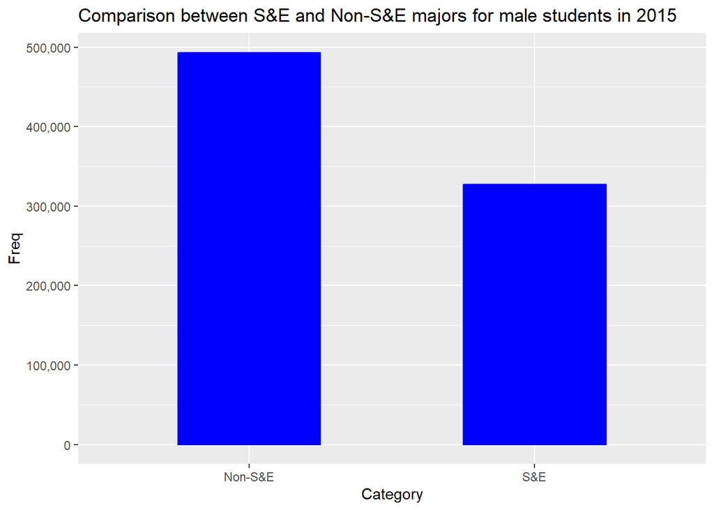

```r
# 2015 Male S&E and non-S&E
ggplot(filter(data2_sum, Sex == "Male"),
  aes(x = Category , y = Freq)) +
  geom_bar(stat = "identity", width=.5, colour="blue", fill="blue") +
  ggtitle("Comparison between S&E and Non-S&E majors for male students in 2015") +
  scale_y_continuous(labels = comma, breaks = seq(0, 1000000, by=100000))
```

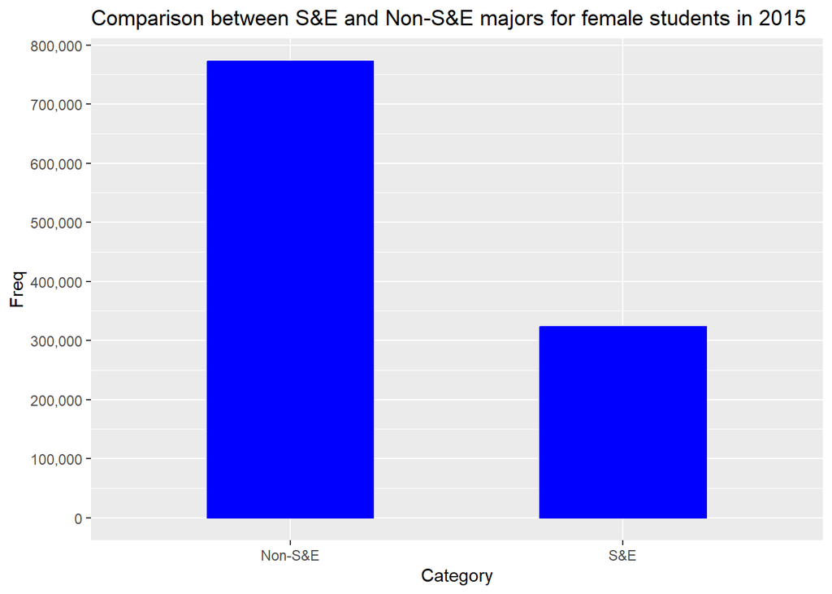

```r
# 2015 Female S&E and non-S&E
ggplot(filter(data2_sum, Sex == "Female"),
  aes(x = Category , y = Freq)) +
  geom_bar(stat = "identity", width=.5, colour="blue", fill="blue") +
  ggtitle("Comparison between S&E and Non-S&E majors for female students in 2015") + scale_y_continuous(labels = comma, breaks = seq(0, 1500000, by=100000))
```

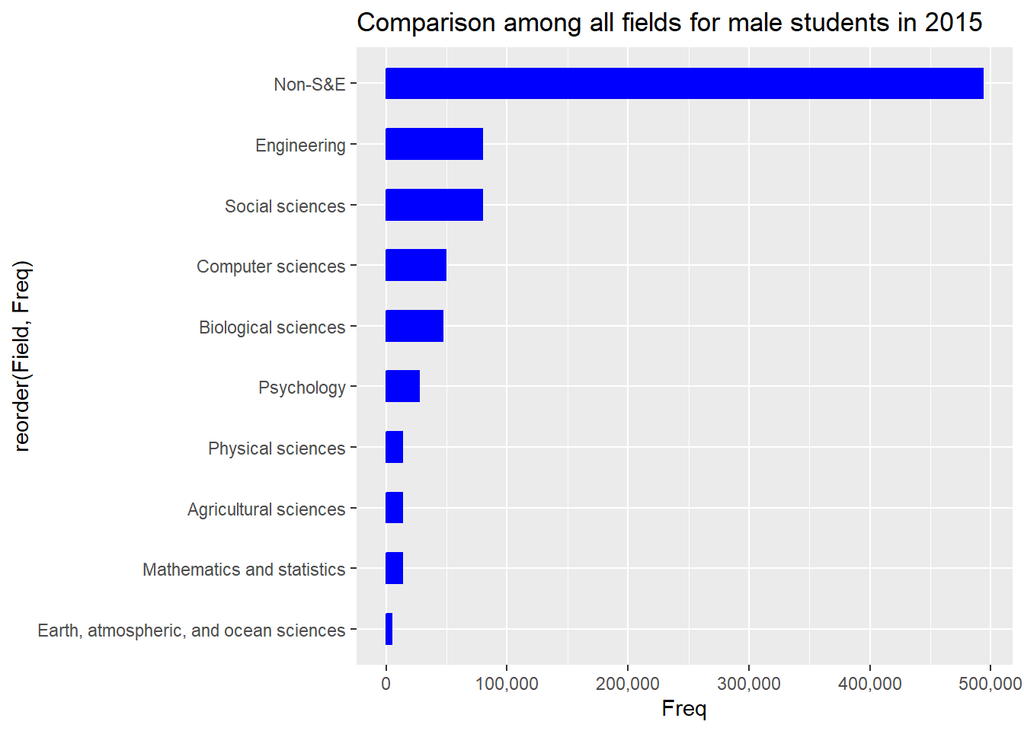

```r
# 2015 Male All Fields
ggplot(filter(data2_sum2, Sex == "Male"),
  aes(x= reorder(Field, Freq), y = Freq)) +
  geom_bar(stat = "identity", width=.5, colour="blue", fill="blue") +
  ggtitle("Comparison among all fields for male students in 2015") +
  scale_y_continuous(labels = comma, breaks = seq(0, 1000000, by=100000)) + coord_flip()
```

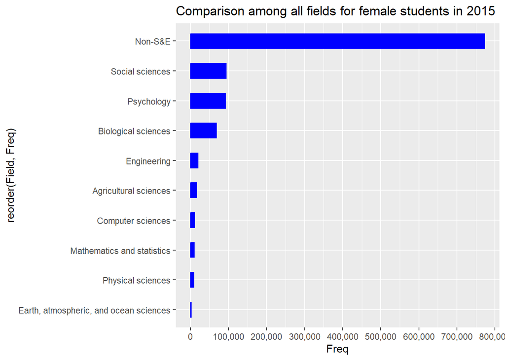

```r
# 2015 Female All Fields
ggplot(filter(data2_sum2, Sex == "Female"),
  aes(x= reorder(Field, Freq), y = Freq)) +
  geom_bar(stat = "identity", width=.5, colour="blue", fill="blue") +
  ggtitle("Comparison among all fields for female students in 2015") +
  scale_y_continuous(labels = comma, breaks = seq(0, 1000000, by=100000)) + coord_flip()
```

## Analysis

Gender effects over different types of degrees: female students outnumber male students overall, but the gap closes the more advanced the degree. For example, female students outnumber male students by ~280k for BS degrees, ~150k for MS degrees, and by only ~200 for PhD degrees.

When considering all degree types (BS, MS, and PhD as opposed to just BS in the previous problem), women are slightly underrepresented in 2015, making up 48.4% of those in the S&E field.

```r
data2_2015b <- filter(data2, Year == 2015)
data2_sumb <- data2_2015b %>% group_by(Category, Sex) %>% summarise(Freq = sum(Number))
data2_sum2b <- data2_2015b %>% group_by(Field, Sex) %>% summarise(Freq = sum(Number))
data2_sum3b <- data2_2015b %>% group_by(Degree, Sex) %>% summarise(Freq = sum(Number))
data2_sumb
```

```
## # A tibble: 4 × 3
## # Groups:   Category [2]
##   Category Sex       Freq
##   <chr>    <chr>    <dbl>
## 1 Non-S&E  Female 1165188
## 2 Non-S&E  Male    713846
## 3 S&E      Female  420872
## 4 S&E      Male    449318
```

```r
data2_sum2b
```

```
## # A tibble: 20 × 3
## # Groups:   Field [10]
##    Field                                  Sex       Freq
##    <chr>                                  <chr>    <dbl>
##  1 Agricultural sciences                  Female   20127
##  2 Agricultural sciences                  Male     16506
##  3 Biological sciences                    Female   81075
##  4 Biological sciences                    Male     56309
##  5 Computer sciences                      Female   20909
##  6 Computer sciences                      Male     72903
##  7 Earth, atmospheric, and ocean sciences Female    4015
##  8 Earth, atmospheric, and ocean sciences Male      6179
##  9 Engineering                            Female   34765
## 10 Engineering                            Male    124754
## 11 Mathematics and statistics             Female   13805
## 12 Mathematics and statistics             Male     19402
## 13 Non-S&E                                Female 1165188
## 14 Non-S&E                                Male    713846
## 15 Physical sciences                      Female   12090
## 16 Physical sciences                      Male     20106
## 17 Psychology                             Female  113957
## 18 Psychology                             Male     33373
## 19 Social sciences                        Female  120129
## 20 Social sciences                        Male     99786
```

```r
data2_sum3b
```

```
## # A tibble: 6 × 3
## # Groups:   Degree [3]
##   Degree Sex       Freq
##   <chr>  <chr>    <dbl>
## 1 BS     Female 1095703
## 2 BS     Male    820426
## 3 MS     Female  455697
## 4 MS     Male    308283
## 5 PhD    Female   34660
## 6 PhD    Male     34455
```

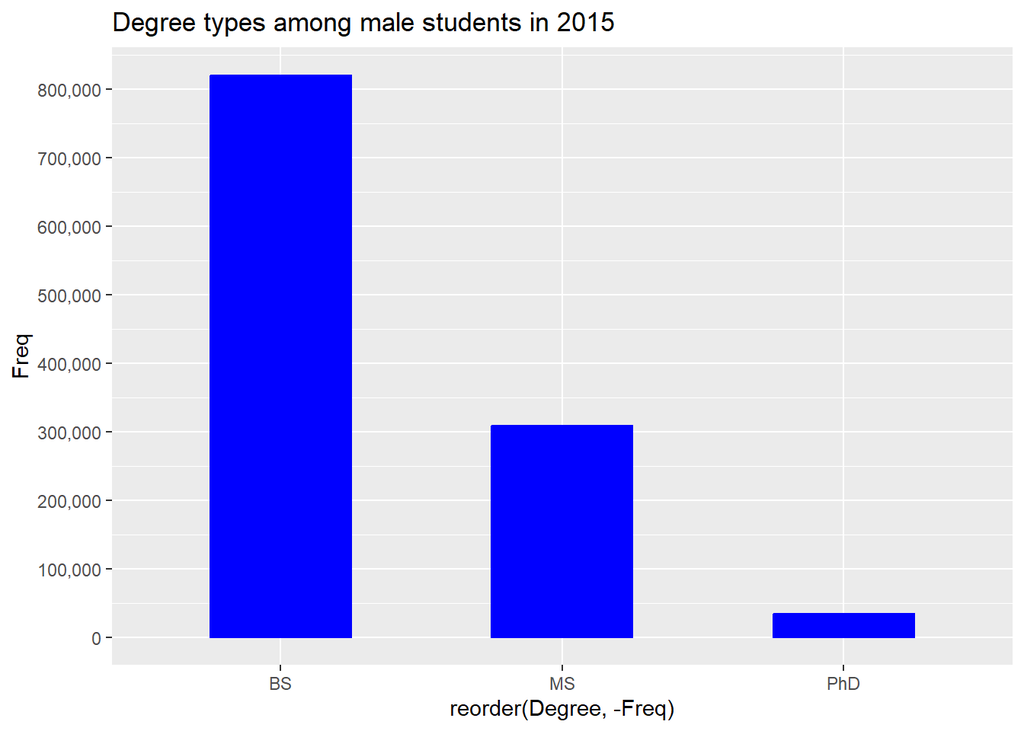

```r
# 2015 male degree types
ggplot(filter(data2_sum3b, Sex == "Male"),
  aes(x= reorder(Degree, -Freq), y = Freq)) +
  geom_bar(stat = "identity", width=.5, colour="blue", fill="blue") +
  ggtitle("Degree types among male students in 2015") +
  scale_y_continuous(labels = comma, breaks = seq(0, 1500000, by=100000))
```

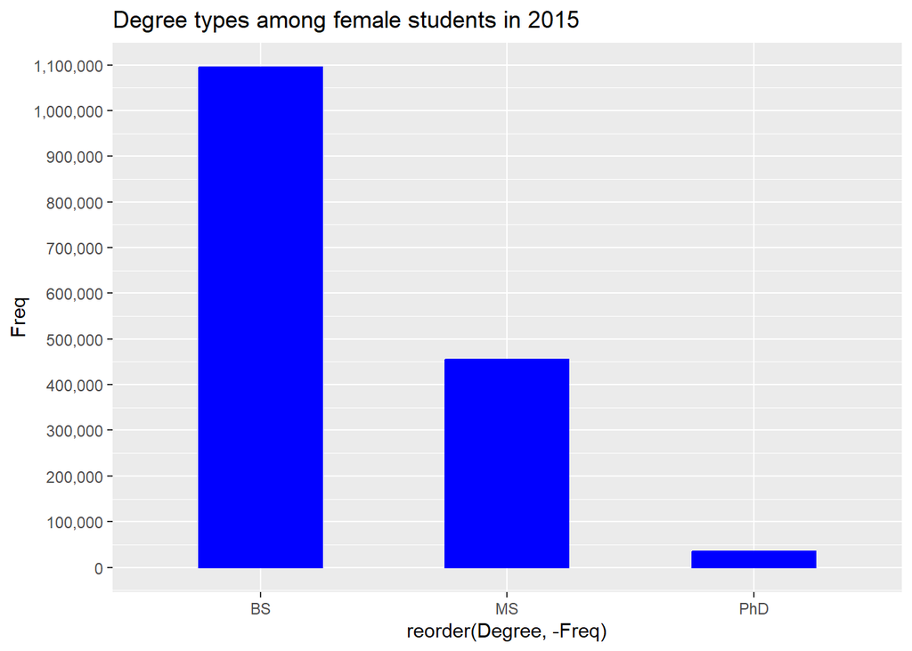

```r
# 2015 female degree types
ggplot(filter(data2_sum3b, Sex == "Female"),
  aes(x= reorder(Degree, -Freq), y = Freq)) +
  geom_bar(stat = "identity", width=.5, colour="blue", fill="blue") +
  ggtitle("Degree types among female students in 2015") +
  scale_y_continuous(labels = comma, breaks = seq(0, 1500000, by=100000))
```

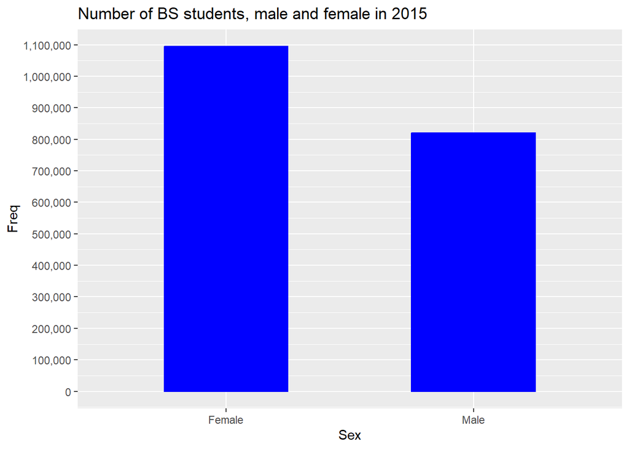

```r
# 2015 BS
ggplot(filter(data2_sum3b, Degree == "BS"),
  aes(x= Sex, y = Freq)) +
  geom_bar(stat = "identity", width=.5, colour="blue", fill="blue") +
  ggtitle("Number of BS students, male and female in 2015") +
  scale_y_continuous(labels = comma, breaks = seq(0, 1500000, by=100000))
```

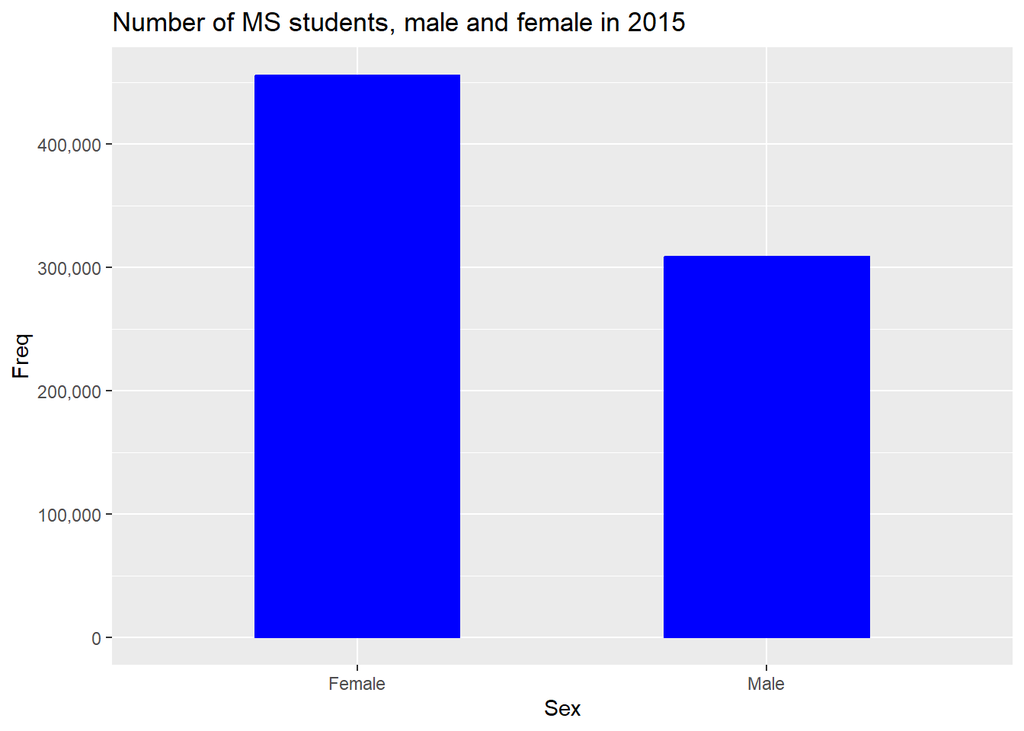

```r
# 2015 MS
ggplot(filter(data2_sum3b, Degree == "MS"),
  aes(x= Sex, y = Freq)) +
  geom_bar(stat = "identity", width=.5, colour="blue", fill="blue") +
  ggtitle("Number of MS students, male and female in 2015") +
  scale_y_continuous(labels = comma, breaks = seq(0, 1500000, by=100000))
```

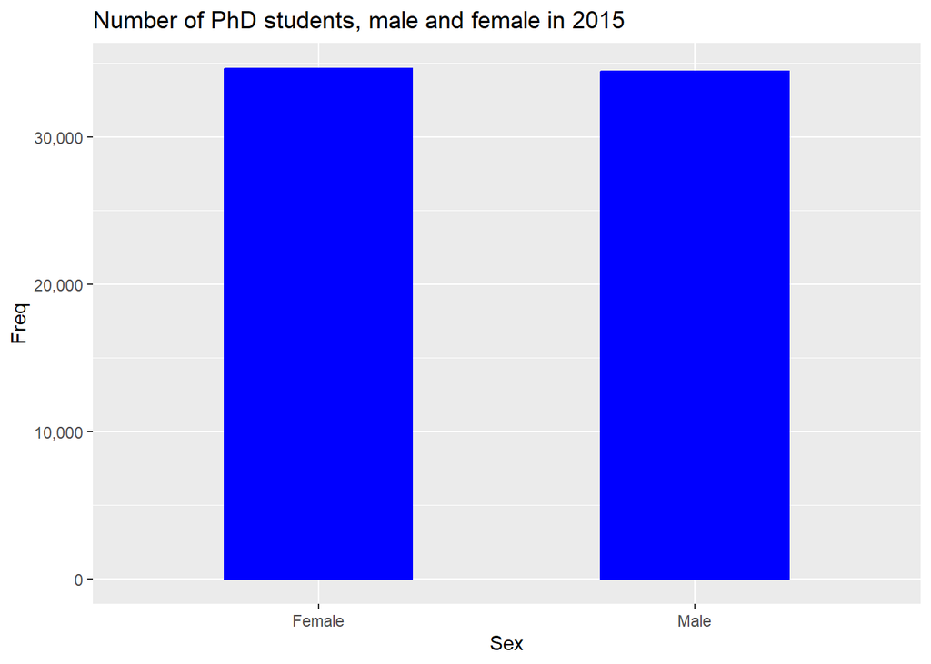

```r
# 2015 PhD
ggplot(filter(data2_sum3b, Degree == "PhD"),
  aes(x= Sex, y = Freq)) +
  geom_bar(stat = "identity", width=.5, colour="blue", fill="blue") +
  ggtitle("Number of PhD students, male and female in 2015") +
  scale_y_continuous(labels = comma, breaks = seq(0, 50000, by=10000))
```

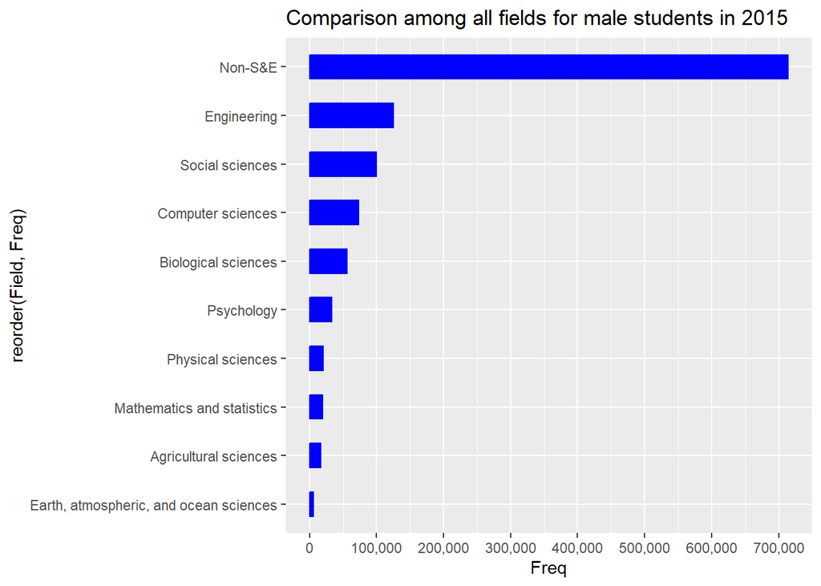

```r
# 2015 Male All Fields
ggplot(filter(data2_sum2b, Sex == "Male"),
  aes(x= reorder(Field, Freq), y = Freq)) +
  geom_bar(stat = "identity", width=.5, colour="blue", fill="blue") +
  ggtitle("Comparison among all fields for male students in 2015") +
  scale_y_continuous(labels = comma, breaks = seq(0, 1000000, by=100000)) + coord_flip()
```

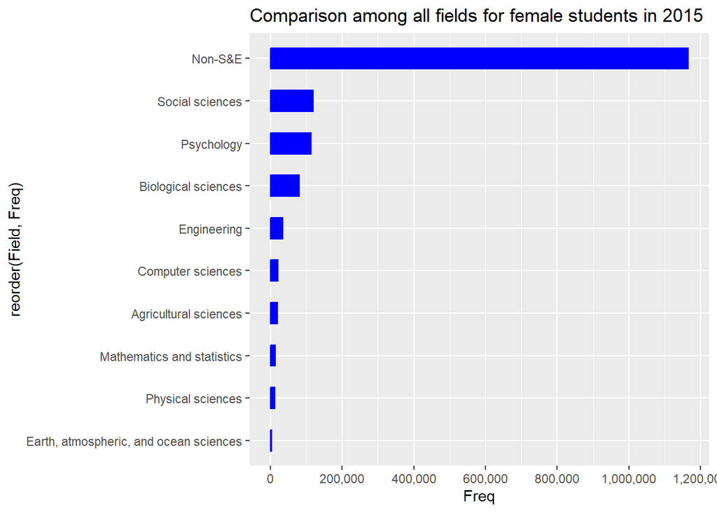

```r
# 2015 Female All Fields
ggplot(filter(data2_sum2b, Sex == "Female"),
  aes(x= reorder(Field, Freq), y = Freq)) +
  geom_bar(stat = "identity", width=.5, colour="blue", fill="blue") +
  ggtitle("Comparison among all fields for female students in 2015") +
  scale_y_continuous(labels = comma, breaks = seq(0, 1500000, by=200000)) + coord_flip()
```

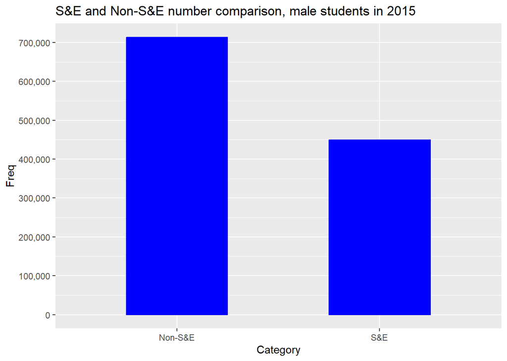

```r
# 2015 Male S&E and non-S&E
ggplot(filter(data2_sumb, Sex == "Male"),
  aes(x = Category , y = Freq)) +
  geom_bar(stat = "identity", width=.5, colour="blue", fill="blue") +
  ggtitle("S&E and Non-S&E number comparison, male students in 2015") +
  scale_y_continuous(labels = comma, breaks = seq(0, 1000000, by=100000))
```

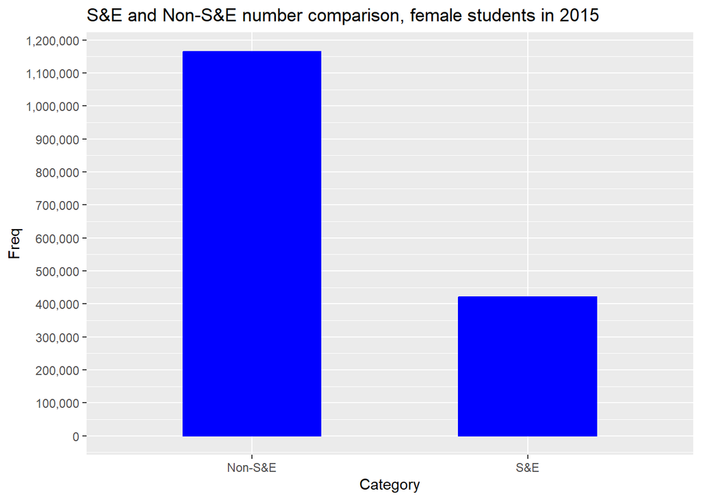

```r
# 2015 Female S&E and non-S&E
ggplot(filter(data2_sumb, Sex == "Female"),
  aes(x = Category , y = Freq)) +
  geom_bar(stat = "identity", width=.5, colour="blue", fill="blue") +
  ggtitle("S&E and Non-S&E number comparison, female students in 2015") + scale_y_continuous(labels = comma, breaks = seq(0, 1500000, by=100000))
```

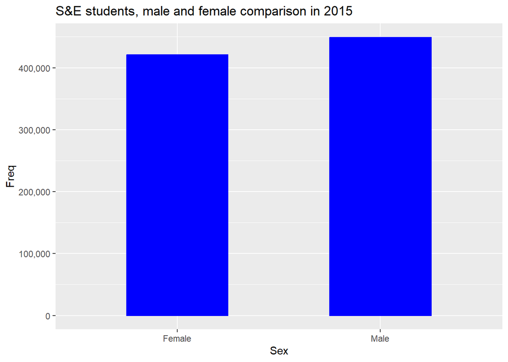

```r
# 2015 S&E Male and Female
ggplot(filter(data2_sumb, Category == "S&E"),
  aes(x = Sex , y = Freq)) +
  geom_bar(stat = "identity", width=.5, colour="blue", fill="blue") +
  ggtitle("S&E students, male and female comparison in 2015") + scale_y_continuous(labels = comma, breaks = seq(0, 1500000, by=100000))
```

## Analysis

the number of S&E majors increased steadily from 2006-2016.

From 2006 to 2016 the number of Female S&E majors increased from 307,708 to 434,609, and the number of Male S&E majors from 322,601 to 468,893.

```r
data2_year <- data2 %>% group_by(Year, Sex, Category) %>% summarise(Freq = sum(Number))
data2_year_sum <- data2 %>% group_by(Sex, Category) %>% summarise(Freq = sum(Number))
```

[output not shown]

```r
data2_year
```

```
## # A tibble: 44 × 4
## # Groups:   Year, Sex [22]
##     Year Sex    Category   Freq
##    <dbl> <chr>  <chr>     <dbl>
##  1  2006 Female Non-S&E  946209
##  2  2006 Female S&E      307708
##  3  2006 Male   Non-S&E  582078
##  4  2006 Male   S&E      322601
##  5  2007 Female Non-S&E  975280
##  6  2007 Female S&E      312159
##  7  2007 Male   Non-S&E  599142
##  8  2007 Male   S&E      326479
##  9  2008 Female Non-S&E  999859
## 10  2008 Female S&E      320621
## # ℹ 34 more rows
```

```r
data2_year_sum
```

```
## # A tibble: 4 × 3
## # Groups:   Sex [2]
##   Sex    Category     Freq
##   <chr>  <chr>       <dbl>
## 1 Female Non-S&E  11916324
## 2 Female S&E       4027920
## 3 Male   Non-S&E   7356720
## 4 Male   S&E       4232238
```

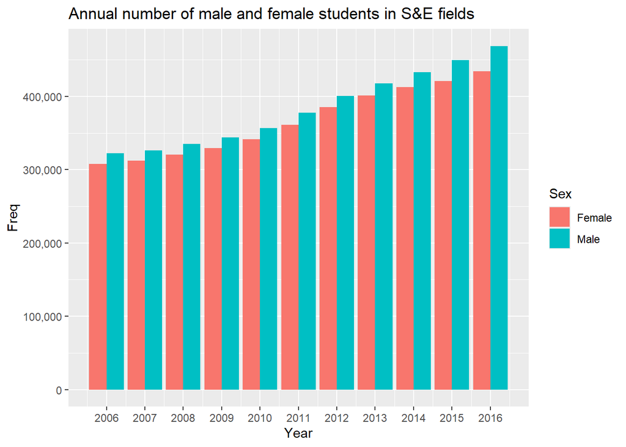

```r
ggplot(filter(data2_year, Category == "S&E"), aes(fill=Sex, y=Freq, x=Year)) +
    geom_bar(position="dodge", stat="identity") +
  ggtitle("Annual number of male and female students in S&E fields") +
  scale_x_continuous(breaks = seq(2000, 2022, by = 1)) +
  scale_y_continuous(labels = comma, breaks = seq(0, 1500000, by=100000))
```

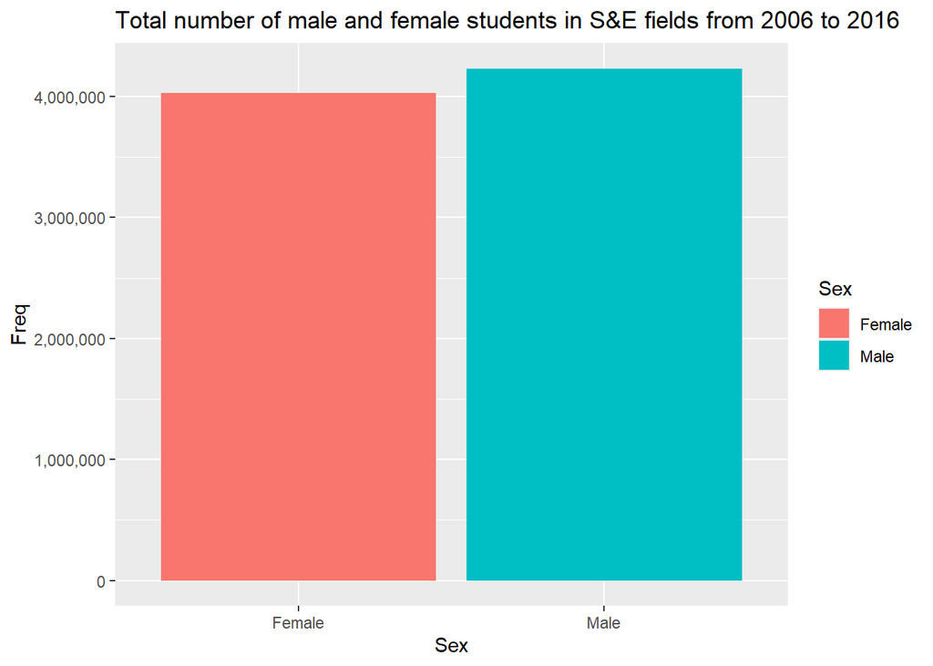

```r
ggplot(filter(data2_year_sum, Category == "S&E"), aes(fill=Sex, y=Freq, x=Sex)) +
    geom_bar(position="dodge", stat="identity") +
  ggtitle("Total number of male and female students in S&E fields from 2006 to 2016") +
  scale_y_continuous(labels = comma, breaks = seq(0, 5000000, by=1000000))
```

## Women in Data Science

From 2006 to 2016 male students outnumber female students by the approximate ratio of 8 to 3.

```r
data2 <- data2 %>% mutate(Category2 = if_else(Field %in% c("Computer sciences", "Mathematics and statistics"), "Data Science", "Non-Data Science"))

data2_year_ds <- data2 %>% group_by(Year, Sex, Category2) %>% summarise(Freq = sum(Number))
data2_year_ds_sum <- data2 %>% group_by(Sex, Category2) %>% summarise(Freq = sum(Number))
```

[output not shown]

```r
data2_year_ds <- filter(data2_year_ds, Category2 == "Data Science")

data2_year_ds_sum <- filter(data2_year_ds_sum, Category2 == "Data Science")

data2_year_ds
```

```
## # A tibble: 22 × 4
## # Groups:   Year, Sex [22]
##     Year Sex    Category2     Freq
##    <dbl> <chr>  <chr>        <dbl>
##  1  2006 Female Data Science 24210
##  2  2006 Male   Data Science 63841
##  3  2007 Female Data Science 21879
##  4  2007 Male   Data Science 60570
##  5  2008 Female Data Science 21440
##  6  2008 Male   Data Science 58684
##  7  2009 Female Data Science 21807
##  8  2009 Male   Data Science 59454
##  9  2010 Female Data Science 22705
## 10  2010 Male   Data Science 61368
## # ℹ 12 more rows
```

```r
data2_year_ds_sum
```

```
## # A tibble: 2 × 3
## # Groups:   Sex [2]
##   Sex    Category2      Freq
##   <chr>  <chr>         <dbl>
## 1 Female Data Science 296891
## 2 Male   Data Science 799889
```

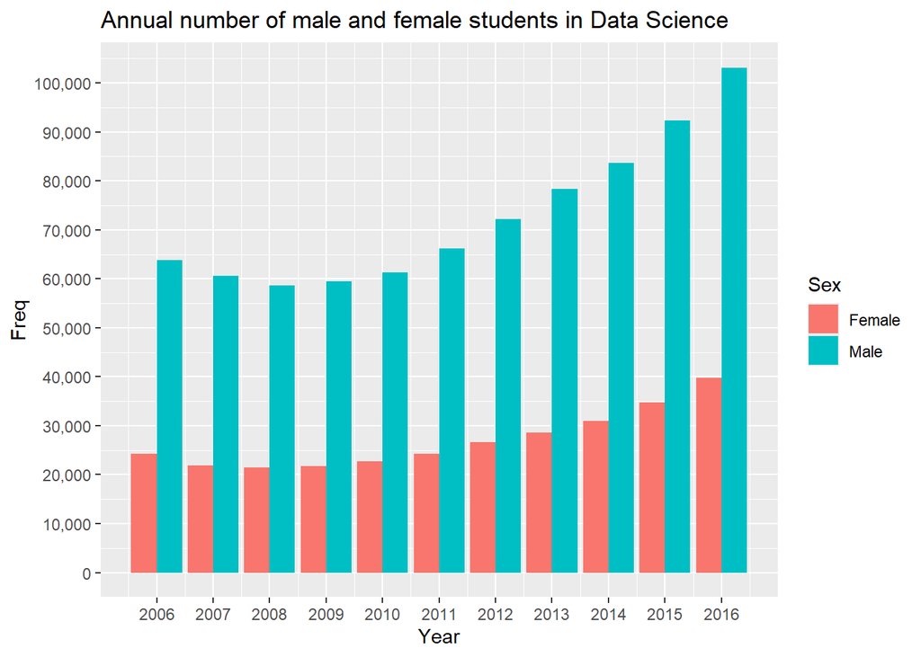

```r
ggplot(filter(data2_year_ds, Category2 == "Data Science"), aes(fill=Sex, y=Freq, x=Year)) +
    geom_bar(position="dodge", stat="identity") +
  ggtitle("Annual number of male and female students in Data Science") +
  scale_x_continuous(breaks = seq(2000, 2022, by = 1)) +
  scale_y_continuous(labels = comma, breaks = seq(0, 150000, by=10000))
```

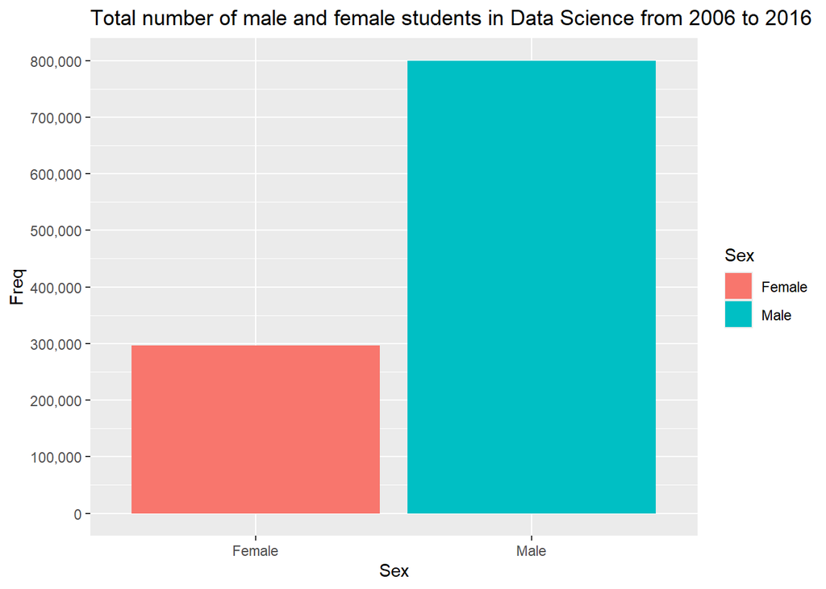

```r
ggplot(data2_year_ds_sum, aes(fill=Sex, y=Freq, x=Sex)) +
    geom_bar(position="dodge", stat="identity") +
  ggtitle("Total number of male and female students in Data Science from 2006 to 2016") +
  scale_y_continuous(labels = comma, breaks = seq(0, 1000000, by=100000))
```

## Conclusion

The dataset seems to suffice for the purposes of the study. However it could be beneficial to have a more granular view of the majors being pursued (i.e. instead of ‘engineering’ we have chemical engineering, mechanical engineering, etc). And one way we can improve the study is by measuring also how women are being represented in each of these fields. For example, in the field of Psychology and Social sciences women significantly outnumber men, and in the field of Data Science the reverse is true, as we have seen above.

```r
ggplot(filter(data2_year, Category == "S&E"), aes(fill=Sex, y=Freq, x=Year)) +
    geom_bar(position="dodge", stat="identity") +
  ggtitle("Annual number of male and female students in S&E fields") +
  scale_x_continuous(breaks = seq(2000, 2022, by = 1)) +
  scale_y_continuous(labels = comma, breaks = seq(0, 1500000, by=100000))

ggplot(filter(data2_year_ds, Category2 == "Data Science"), aes(fill=Sex, y=Freq, x=Year)) +
    geom_bar(position="dodge", stat="identity") +
  ggtitle("Annual number of male and female students in Data Science") +
  scale_x_continuous(breaks = seq(2000, 2022, by = 1)) +
  scale_y_continuous(labels = comma, breaks = seq(0, 150000, by=10000))
```

[output not shown]